# Lab 5: Wide and Deep Networks

##### Group Members: Eric Houtman, Rick Lattin, Kellen Long

In this lab, we explored the successfulness of video games in [this dataset.](https://www.kaggle.com/datasets/ibriiee/video-games-sales-dataset-2022-updated-extra-feat?resource=download) It contains 16,598 video games with sales greater than 100,000 copies. The dataset contains 16 columns, including the name, platform, genre, publisher, developer, critic score, user score, total sales, and more. We will use this dataset to predict the total sales of a video game based on its other features.

For calculating the algorithm's performance, we used the f-1 score as well as the accuracy to adequately measure both the accuracy and precision of the predictions made by our model. For the dataset, the output value is the success of the game, which, using accuracy as a metric is not a bad idea. That is because the output is binary (did it sell more than 2 million copies globally or not). In the case of the f-1 score, it is a comprehensive metric that takes into account the false positives and false negatives, being the harmonic mean of precision and recall.

For dividing our data into training and testing, we used stratified k fold with 10 folds. We felt this would give us accurate splitting and segmentation of data by reducing the bias sampling by making sure that each fold is representative and effectivley dealing with any imbalances that were present in our dataset.

```python
#read in the data from vgsales.csv
import pandas as pd
import numpy as np
import matplotlib.pyplot as plt
import seaborn as sns
import copy

import pandas as pd
import numpy as np
import matplotlib.pyplot as plt
from sklearn.metrics import accuracy_score
from sklearn.preprocessing import LabelEncoder
from sklearn.preprocessing import StandardScaler
from sklearn.model_selection import cross_val_score
from sklearn.model_selection import KFold, ShuffleSplit
from sklearn.model_selection import StratifiedKFold, StratifiedShuffleSplit
from sklearn.metrics import make_scorer, accuracy_score
from sklearn.linear_model import LogisticRegression

#ignore the warning
import warnings
warnings.filterwarnings('ignore')
```

## Processing

```python
df = pd.read_csv('Video_Games.csv')
df.head()
```

|  | Name | Platform | Year_of_Release | Genre | Publisher | NA_Sales | EU_Sales | JP_Sales | Other_Sales | Global_Sales | Critic_Score | Critic_Count | User_Score | User_Count | Developer | Rating |
| --- | --- | --- | --- | --- | --- | --- | --- | --- | --- | --- | --- | --- | --- | --- | --- | --- |
| 0 | Wii Sports | Wii | 2006.0 | Sports | Nintendo | 41.36 | 28.96 | 3.77 | 8.45 | 82.53 | 76.0 | 51.0 | 8 | 322.0 | Nintendo | E |
| 1 | Super Mario Bros. | NES | 1985.0 | Platform | Nintendo | 29.08 | 3.58 | 6.81 | 0.77 | 40.24 | NaN | NaN | NaN | NaN | NaN | NaN |
| 2 | Mario Kart Wii | Wii | 2008.0 | Racing | Nintendo | 15.68 | 12.76 | 3.79 | 3.29 | 35.52 | 82.0 | 73.0 | 8.3 | 709.0 | Nintendo | E |
| 3 | Wii Sports Resort | Wii | 2009.0 | Sports | Nintendo | 15.61 | 10.93 | 3.28 | 2.95 | 32.77 | 80.0 | 73.0 | 8 | 192.0 | Nintendo | E |
| 4 | Pokemon Red/Pokemon Blue | GB | 1996.0 | Role-Playing | Nintendo | 11.27 | 8.89 | 10.22 | 1.00 | 31.37 | NaN | NaN | NaN | NaN | NaN | NaN |

```python
#remove any null values
df = df.dropna()
df.head()
```

|  | Name | Platform | Year_of_Release | Genre | Publisher | NA_Sales | EU_Sales | JP_Sales | Other_Sales | Global_Sales | Critic_Score | Critic_Count | User_Score | User_Count | Developer | Rating |
| --- | --- | --- | --- | --- | --- | --- | --- | --- | --- | --- | --- | --- | --- | --- | --- | --- |
| 0 | Wii Sports | Wii | 2006.0 | Sports | Nintendo | 41.36 | 28.96 | 3.77 | 8.45 | 82.53 | 76.0 | 51.0 | 8 | 322.0 | Nintendo | E |
| 2 | Mario Kart Wii | Wii | 2008.0 | Racing | Nintendo | 15.68 | 12.76 | 3.79 | 3.29 | 35.52 | 82.0 | 73.0 | 8.3 | 709.0 | Nintendo | E |
| 3 | Wii Sports Resort | Wii | 2009.0 | Sports | Nintendo | 15.61 | 10.93 | 3.28 | 2.95 | 32.77 | 80.0 | 73.0 | 8 | 192.0 | Nintendo | E |
| 6 | New Super Mario Bros. | DS | 2006.0 | Platform | Nintendo | 11.28 | 9.14 | 6.50 | 2.88 | 29.80 | 89.0 | 65.0 | 8.5 | 431.0 | Nintendo | E |
| 7 | Wii Play | Wii | 2006.0 | Misc | Nintendo | 13.96 | 9.18 | 2.93 | 2.84 | 28.92 | 58.0 | 41.0 | 6.6 | 129.0 | Nintendo | E |

```python
#drop the columns name, EU_Sales, Other_Sales
df = df.drop(['Name', 'EU_Sales', 'Other_Sales'], axis=1)

#categorize the Global sales into more than 2 million sales and less than 2 million sales
df['Global_Sales'] = df['Global_Sales'].apply(lambda x: 1 if x > 2 else 0)

#categorize the Global_Sales column into quartiles
# df['Global_Sales'] = pd.qcut(df['Global_Sales'], 4, labels=False)

#rename the Year_of_Release column to Year
df = df.rename(columns={'Year_of_Release': 'Year'})


df.head()
```

|  | Platform | Year | Genre | Publisher | NA_Sales | JP_Sales | Global_Sales | Critic_Score | Critic_Count | User_Score | User_Count | Developer | Rating |
| --- | --- | --- | --- | --- | --- | --- | --- | --- | --- | --- | --- | --- | --- |
| 0 | Wii | 2006.0 | Sports | Nintendo | 41.36 | 3.77 | 1 | 76.0 | 51.0 | 8 | 322.0 | Nintendo | E |
| 2 | Wii | 2008.0 | Racing | Nintendo | 15.68 | 3.79 | 1 | 82.0 | 73.0 | 8.3 | 709.0 | Nintendo | E |
| 3 | Wii | 2009.0 | Sports | Nintendo | 15.61 | 3.28 | 1 | 80.0 | 73.0 | 8 | 192.0 | Nintendo | E |
| 6 | DS | 2006.0 | Platform | Nintendo | 11.28 | 6.50 | 1 | 89.0 | 65.0 | 8.5 | 431.0 | Nintendo | E |
| 7 | Wii | 2006.0 | Misc | Nintendo | 13.96 | 2.93 | 1 | 58.0 | 41.0 | 6.6 | 129.0 | Nintendo | E |

```python
#create a list of the headers of all numerical columns
numerical_columns = ['NA_Sales', 'JP_Sales', 'Critic_Score', 'Critic_Count', 'User_Score', 'User_Count']

#create a list of the headers of all categorical columns
categorical_columns = ['Platform', 'Year', 'Genre', 'Publisher', 'Developer', 'Rating']

target_column = 'Global_Sales'

df_imputed = copy.deepcopy(df)

# define vars to encode as integer
encoders = dict()

# encode categorical columns
for col in categorical_columns:
    # integer encode strings that are features
    encoders[col] = LabelEncoder() # save the encoder
    df_imputed[col+'_int'] = encoders[col].fit_transform(df_imputed[col])

# scale numerical columns
scaler = StandardScaler()
df_imputed[numerical_columns] = scaler.fit_transform(df_imputed[numerical_columns])

df_imputed.head()
```

|  | Platform | Year | Genre | Publisher | NA_Sales | JP_Sales | Global_Sales | Critic_Score | Critic_Count | User_Score | User_Count | Developer | Rating | Platform_int | Year_int | Genre_int | Publisher_int | Developer_int | Rating_int |
| --- | --- | --- | --- | --- | --- | --- | --- | --- | --- | --- | --- | --- | --- | --- | --- | --- | --- | --- | --- |
| 0 | Wii | 2006.0 | Sports | Nintendo | 42.349741 | 12.887711 | 1 | 0.413044 | 1.148059 | 0.565602 | 0.250734 | Nintendo | E | 12 | 14 | 10 | 160 | 771 | 1 |
| 2 | Wii | 2008.0 | Racing | Nintendo | 15.802014 | 12.957265 | 1 | 0.845709 | 2.292536 | 0.773959 | 0.909586 | Nintendo | E | 12 | 16 | 6 | 160 | 771 | 1 |
| 3 | Wii | 2009.0 | Sports | Nintendo | 15.729649 | 11.183651 | 1 | 0.701487 | 2.292536 | 0.565602 | 0.029415 | Nintendo | E | 12 | 17 | 10 | 160 | 771 | 1 |
| 6 | DS | 2006.0 | Platform | Nintendo | 11.253338 | 22.381762 | 1 | 1.350484 | 1.876363 | 0.912863 | 0.436302 | Nintendo | E | 2 | 14 | 4 | 160 | 771 | 1 |
| 7 | Wii | 2006.0 | Misc | Nintendo | 14.023895 | 9.966465 | 1 | -0.884950 | 0.627843 | -0.406731 | -0.077840 | Nintendo | E | 12 | 14 | 3 | 160 | 771 | 1 |

```python
categorical_headers_ints = [x+'_int' for x in categorical_columns]
feature_headers = numerical_columns + categorical_headers_ints
feature_headers
```

```
['NA_Sales',
 'JP_Sales',
 'Critic_Score',
 'Critic_Count',
 'User_Score',
 'User_Count',
 'Platform_int',
 'Year_int',
 'Genre_int',
 'Publisher_int',
 'Developer_int',
 'Rating_int']
```

```python
print("\nCategorical String Headers: ", categorical_columns)
print("\nCategorical Integer Headers: ", categorical_headers_ints)
```

```
Categorical String Headers:  ['Platform', 'Year', 'Genre', 'Publisher', 'Developer', 'Rating']

Categorical Integer Headers:  ['Platform_int', 'Year_int', 'Genre_int', 'Publisher_int', 'Developer_int', 'Rating_int']
```

```python
#split the data into X and y
X = df_imputed[feature_headers].to_numpy()
y = df_imputed['Global_Sales'].values

#check the shape of X and y
print(X.shape)
print(y.shape)
```

```
(6825, 12)
(6825,)
```

```python
num_instances = len(y)
cv_object = StratifiedKFold(n_splits=10)

for df_train, df_test in cv_object.split(X,y):
    X_train = X[df_train]
    y_train = y[df_train]

    X_test = X[df_test]
    y_test = y[df_test]

#check the shape of x_train and y_train
print(X_train.shape)
print(y_train.shape)

#check the shape of x_test and y_test
print(X_test.shape)
print(y_test.shape)

#test the accuracy of the model
lr = LogisticRegression()
lr.fit(X_train, y_train)
y_pred = lr.predict(X_test)
print("Accuracy: ", accuracy_score(y_test, y_pred))
```

```
(6143, 12)
(6143,)
(682, 12)
(682,)
Accuracy:  0.9530791788856305
```

Above is where we impliment the stratified K fold method of data splitting that we described at the top of the lab.

```
Recall score average: 79.46428571428571
```

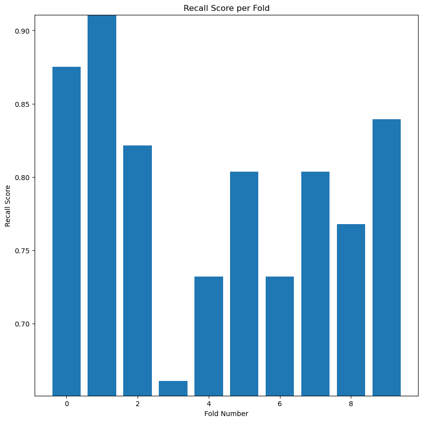

```python
from sklearn.metrics import make_scorer, recall_score
from sklearn.linear_model import LogisticRegression

# select model
clf = LogisticRegression()
clf.fit(X,y)

#select cross validation
cv = StratifiedShuffleSplit(n_splits=10)
# select evaluation criteria
my_scorer = make_scorer(recall_score)

# run model training and cross validation
per_fold_eval_criteria = cross_val_score(estimator=clf,
                                    X=X,
                                    y=y,
                                    cv=cv,
                                    scoring=my_scorer
)

plt.figure(figsize=(10,10))
plt.bar(range(len(per_fold_eval_criteria)),per_fold_eval_criteria)
plt.ylim([min(per_fold_eval_criteria)-0.01,max(per_fold_eval_criteria)])

# title and labels
plt.title('Recall Score per Fold')
plt.ylabel('Recall Score')
plt.xlabel('Fold Number')

print(f'Recall score average: {per_fold_eval_criteria.mean()*100}')
plt.show()
```

### Creating Cross-Product columns

```python
cross_columns = [['Platform', 'Genre']]
cross_columns2 = [['Developer', 'Publisher']]
cross_columns3 = [['Platform', 'Publisher'], ['Platform', 'Developer'], ['Platform', 'Genre']]

# cross each set of columns in the list above
cross_col_df_names1 = []
cross_col_df_names2 = []
cross_col_df_names3 = []
def fill_cross_columns(cross_columns):
    cross_col_df_names = []
    for cols_list in cross_columns:
        # encode as ints for the embedding
        enc = LabelEncoder()

        # 1. create crossed labels by join operation
        X_crossed_train = df_imputed[cols_list].apply(lambda x: '_'.join(x), axis=1)

        # get a nice name for this new crossed column
        cross_col_name = '_'.join(cols_list)

        # 2. encode as integers
        enc.fit(np.hstack((X_crossed_train.to_numpy())))

        # 3. Save into dataframe with new name
        df_imputed[cross_col_name] = enc.transform(X_crossed_train)

        # keep track of the new names of the crossed columns
        cross_col_df_names.append(cross_col_name)

    return cross_col_df_names

cross_col_df_names1 = fill_cross_columns(cross_columns)
cross_col_df_names2 = fill_cross_columns(cross_columns2)
cross_col_df_names3 = fill_cross_columns(cross_columns3)
```

```python
df_imputed.head()
```

|  | Platform | Year | Genre | Publisher | NA_Sales | JP_Sales | Global_Sales | Critic_Score | Critic_Count | User_Score | ... | Platform_int | Year_int | Genre_int | Publisher_int | Developer_int | Rating_int | Platform_Genre | Developer_Publisher | Platform_Publisher | Platform_Developer |
| --- | --- | --- | --- | --- | --- | --- | --- | --- | --- | --- | --- | --- | --- | --- | --- | --- | --- | --- | --- | --- | --- |
| 0 | Wii | 2006.0 | Sports | Nintendo | 42.349741 | 12.887711 | 1 | 0.413044 | 1.148059 | 0.565602 | ... | 12 | 14 | 10 | 160 | 771 | 1 | 160 | 1419 | 663 | 2434 |
| 2 | Wii | 2008.0 | Racing | Nintendo | 15.802014 | 12.957265 | 1 | 0.845709 | 2.292536 | 0.773959 | ... | 12 | 16 | 6 | 160 | 771 | 1 | 156 | 1419 | 663 | 2434 |
| 3 | Wii | 2009.0 | Sports | Nintendo | 15.729649 | 11.183651 | 1 | 0.701487 | 2.292536 | 0.565602 | ... | 12 | 17 | 10 | 160 | 771 | 1 | 160 | 1419 | 663 | 2434 |
| 6 | DS | 2006.0 | Platform | Nintendo | 11.253338 | 22.381762 | 1 | 1.350484 | 1.876363 | 0.912863 | ... | 2 | 14 | 4 | 160 | 771 | 1 | 24 | 1419 | 88 | 266 |
| 7 | Wii | 2006.0 | Misc | Nintendo | 14.023895 | 9.966465 | 1 | -0.884950 | 0.627843 | -0.406731 | ... | 12 | 14 | 3 | 160 | 771 | 1 | 153 | 1419 | 663 | 2434 |

5 rows × 23 columns

## Modeling

```python
cat_X = df_imputed[categorical_headers_ints].to_numpy()
cat_y = df_imputed['Global_Sales'].values

# the indices are the rows used for training and testing in each iteration
for df_train, df_test in cv_object.split(cat_X,cat_y):
    X_train_cat = cat_X[df_train]
    y_train_cat = cat_y[df_train]

    X_test_cat = cat_X[df_test]
    y_test_cat = cat_y[df_test]

num_X = df_imputed[numerical_columns].to_numpy()
num_y = df_imputed['Global_Sales'].values # get the labels we want

# the indices are the rows used for training and testing in each iteration
for df_train, df_test in cv_object.split(num_X,num_y):
    X_train_num = num_X[df_train]
    y_train_num = num_y[df_train]

    X_test_num = num_X[df_test]
    y_test_num = num_y[df_test]


cross_X = df_imputed[cross_col_df_names1].to_numpy()
cross_y = df_imputed['Global_Sales'].values

# the indices are the rows used for training and testing in each iteration
for df_train, df_test in cv_object.split(cross_X,cross_y):
    X_train_cross = cross_X[df_train]
    y_train_cross = cross_y[df_train]

    X_test_cross = cross_X[df_test]
    y_test_cross = cross_y[df_test]
```

```python
for col in categorical_columns:
    vals = df_imputed[col].unique()
    print(col,'has', len(vals), 'unique values:')
    print(vals)
```

```
Platform has 17 unique values:
['Wii' 'DS' 'X360' 'PS3' 'PS2' '3DS' 'PS4' 'PS' 'XB' 'PC' 'PSP' 'WiiU'
 'GC' 'GBA' 'XOne' 'PSV' 'DC']
Year has 25 unique values:
[2006. 2008. 2009. 2005. 2007. 2010. 2013. 2004. 2002. 2001. 2011. 2012.
 2014. 1997. 1999. 2015. 2016. 2003. 1998. 1996. 2000. 1994. 1985. 1992.
 1988.]
Genre has 12 unique values:
['Sports' 'Racing' 'Platform' 'Misc' 'Action' 'Puzzle' 'Shooter'
 'Fighting' 'Simulation' 'Role-Playing' 'Adventure' 'Strategy']
Publisher has 262 unique values:
['Nintendo' 'Microsoft Game Studios' 'Take-Two Interactive'
 'Sony Computer Entertainment' 'Activision' 'Ubisoft' 'Bethesda Softworks'
 'Electronic Arts' 'SquareSoft' 'GT Interactive'
 'Konami Digital Entertainment' 'Square Enix'
 'Sony Computer Entertainment Europe' 'Virgin Interactive' 'LucasArts'
 '505 Games' 'Capcom' 'Warner Bros. Interactive Entertainment'
 'Universal Interactive' 'RedOctane' 'Atari' 'Eidos Interactive'
 'Namco Bandai Games' 'Vivendi Games' 'MTV Games' 'Sega' 'THQ'
 'Disney Interactive Studios' 'Acclaim Entertainment' 'Midway Games'
 'Deep Silver' 'NCSoft' 'Tecmo Koei' 'Valve Software' 'Infogrames'
 'Mindscape' 'Valve' 'Hello Games' 'Global Star' 'Gotham Games'
 'Crave Entertainment' 'Hasbro Interactive' 'Codemasters' 'TDK Mediactive'
 'Zoo Games' 'Sony Online Entertainment' 'RTL' 'D3Publisher'
 'Black Label Games' 'SouthPeak Games' 'Zoo Digital Publishing'
 'City Interactive' 'Empire Interactive' 'Russel' 'Atlus' 'Mastertronic'
 'Slightly Mad Studios' 'Play It' 'Tomy Corporation'
 'Focus Home Interactive' 'Unknown' 'Game Factory' 'Titus'
 'Marvelous Entertainment' 'Genki' 'TalonSoft' 'Square Enix ' 'SCi'
 'Rage Software' 'Ubisoft Annecy' 'Rising Star Games' 'Enix Corporation'
 'Level 5' 'Koch Media' 'Square EA' 'Touchstone' 'Spike'
 'Nippon Ichi Software' 'Sony Computer Entertainment America'
 'Illusion Softworks' 'Interplay' 'Metro 3D' 'Rondomedia' 'Ghostlight'
 'Majesco Entertainment' 'PQube' 'Trion Worlds' 'Xseed Games'
 'Ignition Entertainment' 'Kadokawa Shoten' 'Natsume' 'Square'
 'Gamebridge' 'Midas Interactive Entertainment' 'ASCII Entertainment'
 'Rebellion' 'Harmonix Music Systems' 'Activision Blizzard' 'Xplosiv'
 'System 3 Arcade Software' 'Wanadoo' 'NovaLogic' 'BAM! Entertainment'
 'Tetris Online' 'Psygnosis' 'Screenlife' 'GungHo' 'Jester Interactive'
 'Black Bean Games' '3DO' 'Takara Tomy' 'Sammy Corporation' 'Hudson Soft'
```

[output cut: 28 more lines]

```
 'Cloud Imperium Games Corporation' 'Flashpoint Games'
 'Alternative Software' 'DHM Interactive' 'Iceberg Interactive'
 'MC2 Entertainment' '2D Boy' 'Gearbox Software' 'Global A Entertainment'
 'Just Flight' 'bitComposer Games' 'Introversion Software' 'Sold Out'
 'Sunflowers' 'id Software' 'Maxis' 'Pinnacle' 'Xicat Interactive'
 'Devolver Digital' 'Number None' 'Strategy First' 'Lexicon Entertainment'
 'GOA' 'Avanquest' 'Graphsim Entertainment' 'Codemasters Online'
 'Stainless Games' '10TACLE Studios' 'FuRyu Corporation' 'Visco'
 'Crimson Cow' 'Lighthouse Interactive' 'CDV Software Entertainment'
 'Encore' 'Blue Byte' 'NewKidCo']
Developer has 1289 unique values:
['Nintendo' 'Good Science Studio' 'Rockstar North' ... 'Big Red Software'
 'Fluid Studios' 'Atomic Games']
Rating has 7 unique values:
['E' 'M' 'T' 'E10+' 'AO' 'K-A' 'RP']
```

```python
from sklearn import metrics as mt
import tensorflow as tf
from tensorflow import keras
import os
os.environ['KMP_DUPLICATE_LIB_OK']='True'

print(tf.__version__)
print(keras.__version__)
```

```
2.12.0
2.12.0
```

```python
from tensorflow.keras.layers import Dense, Activation, Input
from tensorflow.keras.models import Model
from tensorflow.keras.utils import plot_model

#import embedding layer
from tensorflow.keras.layers import Embedding

#import concatenate layer
from tensorflow.keras.layers import concatenate
```

### First model

```python
# we need to create separate lists for each branch
crossed_outputs = []

# CROSSED DATA INPUT
input_crossed = Input(shape=(X_train_cross.shape[1],), dtype='int64', name='wide_inputs')
for idx,col in enumerate(cross_col_df_names1):

    N = df_imputed[col].max()+1

    # this line of code does this: input_branch[:,idx]
    x = tf.gather(input_crossed, idx, axis=1)

    # now use an embedding to deal with integers as if they were one hot encoded
    x = Embedding(input_dim=N,
                  output_dim=int(np.sqrt(N)),
                  input_length=1, name=col+'_embed')(x)

    # save these outputs to concatenate later
    crossed_outputs.append(x)


# now concatenate the outputs and add a fully connected layer
wide_branch = concatenate(crossed_outputs, name='wide_concat')

# reset this input branch
all_deep_branch_outputs = []

# CATEGORICAL DATA INPUT
input_cat = Input(shape=(X_train_cat.shape[1],), dtype='int64', name='categorical_input')
for idx,col in enumerate(categorical_headers_ints):

    N = df_imputed[col].max()+1

    # this line of code does this: input_branch[:,idx]
    x = tf.gather(input_cat, idx, axis=1)

    # now use an embedding to deal with integers as if they were one hot encoded
    x = Embedding(input_dim=N,
                  output_dim=int(np.sqrt(N)),
                  input_length=1, name=col+'_embed')(x)

    # save these outputs to concatenate later
    all_deep_branch_outputs.append(x)

# NUMERIC DATA INPUT
# create dense input branch for numeric
input_num = Input(shape=(X_train_num.shape[1],), name='numeric')
x_dense = Dense(units=20, activation='relu',name='num_1')(input_num)

all_deep_branch_outputs.append(x_dense)


# merge the deep branches together
deep_branch = concatenate(all_deep_branch_outputs,name='concat_embeds')
deep_branch = Dense(units=50,activation='relu', name='deep1')(deep_branch)
deep_branch = Dense(units=25,activation='relu', name='deep2')(deep_branch)
deep_branch = Dense(units=10,activation='relu', name='deep3')(deep_branch)

# merge the deep and wide branch
final_branch = concatenate([wide_branch, deep_branch],
                           name='concat_deep_wide')
final_branch = Dense(units=1,activation='sigmoid',
                     name='combined')(final_branch)

model = Model(inputs=[input_crossed,input_cat,input_num],
              outputs=final_branch)
```

For our first model we are using the crossed column that is comprised of the platform and the genre of the video games to construct the wide layer of our network. We are using the standard three concatenated deep branches to represent the deep layers and are using the 'units' parameters of 50, 25 and 10 respectivley to control the depth of the network.

```python
# you will need to install pydot properly on your machine to get this running
plot_model(
    model, to_file='model.png', show_shapes=True, show_layer_names=True,
    rankdir='LR', expand_nested=False, dpi=96
)
model.summary()
```

```
Model: "model_10"
__________________________________________________________________________________________________
 Layer (type)                   Output Shape         Param #     Connected to
==================================================================================================
 categorical_input (InputLayer)  [(None, 6)]         0           []

 tf.compat.v1.gather_79 (TFOpLa  (None,)             0           ['categorical_input[0][0]']
 mbda)

 tf.compat.v1.gather_80 (TFOpLa  (None,)             0           ['categorical_input[0][0]']
 mbda)

 tf.compat.v1.gather_81 (TFOpLa  (None,)             0           ['categorical_input[0][0]']
 mbda)

 tf.compat.v1.gather_82 (TFOpLa  (None,)             0           ['categorical_input[0][0]']
 mbda)

 tf.compat.v1.gather_83 (TFOpLa  (None,)             0           ['categorical_input[0][0]']
 mbda)

 tf.compat.v1.gather_84 (TFOpLa  (None,)             0           ['categorical_input[0][0]']
 mbda)

 numeric (InputLayer)           [(None, 6)]          0           []

 Platform_int_embed (Embedding)  (None, 4)           68          ['tf.compat.v1.gather_79[0][0]']

 Year_int_embed (Embedding)     (None, 5)            125         ['tf.compat.v1.gather_80[0][0]']

 Genre_int_embed (Embedding)    (None, 3)            36          ['tf.compat.v1.gather_81[0][0]']

 Publisher_int_embed (Embedding  (None, 16)          4192        ['tf.compat.v1.gather_82[0][0]']
 )

 Developer_int_embed (Embedding  (None, 35)          45115       ['tf.compat.v1.gather_83[0][0]']
 )

 Rating_int_embed (Embedding)   (None, 2)            14          ['tf.compat.v1.gather_84[0][0]']

```

[output cut: 21 more lines]

```

 wide_concat (Concatenate)      (None, 14)           0           ['Platform_Genre_embed[0][0]']

 deep3 (Dense)                  (None, 10)           260         ['deep2[0][0]']

 concat_deep_wide (Concatenate)  (None, 24)          0           ['wide_concat[0][0]',
                                                                  'deep3[0][0]']

 combined (Dense)               (None, 1)            25          ['concat_deep_wide[0][0]']

==================================================================================================
Total params: 58,308
Trainable params: 58,308
Non-trainable params: 0
__________________________________________________________________________________________________
```

```python
from tensorflow.keras.metrics import Recall
from tensorflow.keras.metrics import AUC
```

```python
%%time

model.compile(optimizer='adagrad',
              loss='mean_squared_error',
              metrics=['accuracy'])

# lets also add the history variable to see how we are doing
# and lets add a validation set to keep track of our progress
history = model.fit([X_train_cross,X_train_cat,X_train_num],
                    y_train,
                    epochs=15,
                    batch_size=32,
                    verbose=1,
                    validation_data = ([X_test_cross,X_test_cat,X_test_num],y_test))
```

```
CPU times: user 11 s, sys: 1.47 s, total: 12.4 s
Wall time: 9.56 s
```

```python
history = model.fit([X_train_cross,X_train_cat,X_train_num],
                    y_train,
                    epochs=50,
                    batch_size=32,
                    verbose=0,
                    validation_data = ([X_test_cross,X_test_cat,X_test_num],y_test))
```

```python
all_f1_scores = []
all_acc_scores = []
```

```python
yhat = np.round(model.predict([X_test_cross,X_test_cat,X_test_num]))
print(mt.confusion_matrix(y_test,yhat))
print(mt.classification_report(y_test,yhat))

#save the f1 and accuracy scores from the classification report
f1_score = mt.classification_report(y_test,yhat).split()[7]
all_f1_scores.append(f1_score)
accuracy_score = mt.accuracy_score(y_test,yhat)
all_acc_scores.append(accuracy_score)
print(f1_score)
print(accuracy_score)
```

```
[[626   0]
 [ 52   4]]
              precision    recall  f1-score   support

           0       0.92      1.00      0.96       626
           1       1.00      0.07      0.13        56

    accuracy                           0.92       682
   macro avg       0.96      0.54      0.55       682
weighted avg       0.93      0.92      0.89       682

0.96
0.9237536656891495
```

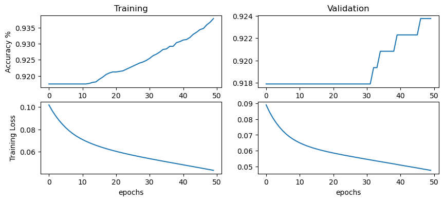

```python
from matplotlib import pyplot as plt

%matplotlib inline

plt.figure(figsize=(10,4))
plt.subplot(2,2,1)
plt.plot(history.history['accuracy'])

plt.ylabel('Accuracy %')
plt.title('Training')
plt.subplot(2,2,2)
plt.plot(history.history['val_accuracy'])
plt.title('Validation')

plt.subplot(2,2,3)
plt.plot(history.history['loss'])
plt.ylabel('Training Loss')
plt.xlabel('epochs')

plt.subplot(2,2,4)
plt.plot(history.history['val_loss'])
plt.xlabel('epochs')
```